# Proyecto fin de curso DataScientist K-School

# Pestaña 1: Top10 relaciones por Categoria

La estructura comercial de los surtidos de articulos Carrefour tiene cuatro niveles anidados.

En esta pestaña es obligatorio seleccionar llegar, a través de los *selectInput* del menu lateral izquierdo, a seleccionar el tercer nivel *familia*

El aplicativo desglosa las categorias (subfamilias) que componen el cuarto nivel de la estructura comercial y por cada una de ellas se identifican las otras 10 categorias que aparecen mas frecuentemente en los tickets en los que aparece la misma.

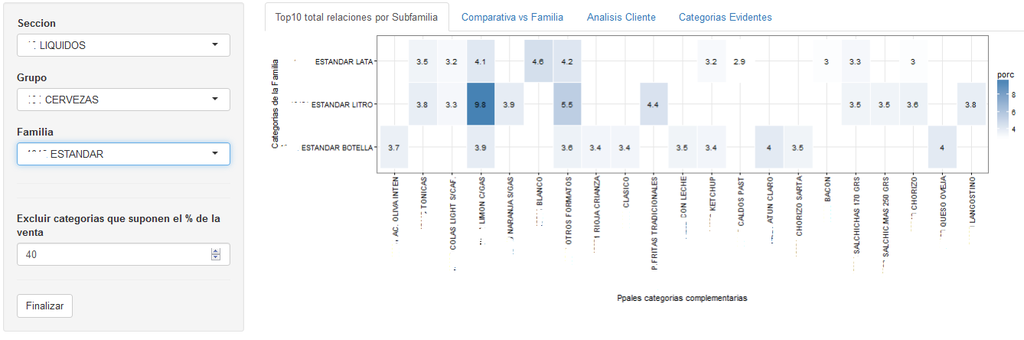

El *numericInput* del menu lateral izquierda excluye de la seleccion de categorias mostradas aquellas que suponen el peso indicado en este selector sobre el total de las relaciones ticket-categoria.

# Pestaña 2: Comparativa vs Familia

Es la misma logica descrita en el punto anterior, pero la busqueda de *categorias complementarias* no es sobre el total de categorias existentes en Carrefour, sino que se centran en una segunda familia en concreta.

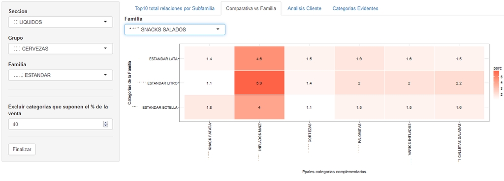

# Pestaña 3: Analisis Cliente

Los *selectInput* del menu lateral izquierdo no aplican en esta pestaña.

A traves de un nuevo *selectInput* se selecciona un cliente concreto. Evidentemente se ha recodificado su identificacion de Tarjeta Club.

El sistema identifica las cinco categorias mas presentes en los tickets del cliente

Por cada una de estas categorias se identifican las cinco categorias que aparecen mas frecuentemente en los tickets en los que aparece la misma. Si aplica el *numericInput* para excluir las *categorias evidentes* como se describia en los puntos anteriores

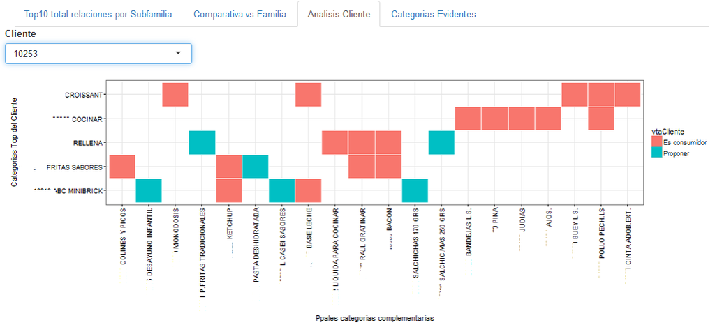

Por cada relacion *categoria Top Cliente / categoria Top complementaria* el color indica si el cliente analizado es consumidor de la categoria complementaria o no, ya que, si no lo es, pareceria interesante proponersela a traves de los cupones destinados a propietarios de Tarjeta Club.